# Practical Machine Learning - Project

Dan Schreck

June 30, 2016

## Overview

The goal of this analysis is to predict the manner in which individuals performed an exercise. Six participants were asked to perform barbell lifts correctly and incorrectly in 5 different ways. In the “classe” variable in the training set an “A” corresponds to the correct execution of the exercise, while the other 4 classes (B through E) correspond to common mistakes. By using data from accelerometers on the belt, forearm, arm, and dumbell we aim to predict which class the observation falls in.

## Data Objects

```r
setwd("/Users/schre/DataScience/wd/machine-learning")
trainUrl <- "http://d396qusza40orc.cloudfront.net/predmachlearn/pml-training.csv"
testUrl <- "http://d396qusza40orc.cloudfront.net/predmachlearn/pml-testing.csv"
training <- read.csv(url(trainUrl), na.strings=c("NA","#DIV/0!",""))
testing <- read.csv(url(testUrl), na.strings=c("NA","#DIV/0!",""))
```

## Data Exploration

The training dataset contains close to 150+ predictors. Let’s first check it for columns with near zero variance. Then we’ll also eliminate those columns which are not truly predictors, namely the first 6 columns. Lastly, we’ll eliminate those columns with a high percentage (50%) of NAs.

```r
nzvTraining <- nearZeroVar(training, saveMetrics=TRUE)
trainingSub <- training[,nzvTraining$nzv==FALSE]

trainingSub <- trainingSub[,7:length(colnames(trainingSub))]

# Count the number of NAs in each col
nonnaCols <- as.vector(apply(trainingSub, 2, function(trainingSub) length(which(!is.na(trainingSub)))))

# Drop columns that have more than 50% NAs
dropNAs <- c()
for (i in 1:length(nonnaCols)) {
    if (nonnaCols[i] > nrow(trainingSub)*.50) {
        dropNAs <- c(dropNAs, colnames(trainingSub)[i])
    }
}

#drop NA data in training and testing
trainingSub <- trainingSub[,(names(trainingSub) %in% dropNAs)]

keepCols <- colnames(trainingSub[, -53]) #remove classe as it's not contained in testing
testingSub <- testing[keepCols] #keep only variables in testing
dim(trainingSub); dim(testingSub) #trainingSub will have 1 more variable - classe
```

```
## [1] 19622    53
```

```
## [1] 20 52
```

We still have a lot of remaining predictors and a rather large training dataset, which is likely too much for many types of analysis, like Random Forest. So, I’ve decided to break it up into three separate data sets.

```r
set.seed(2)
idx1 <- createDataPartition(trainingSub$classe, p=1/3, list=FALSE)
trainingSub1 <- trainingSub[idx1,]
df <- trainingSub[-idx1,]
set.seed(3)
idx2 <- createDataPartition(y=df$classe, p=0.5, list=FALSE)
trainingSub2 <- df[idx2,]
trainingSub3 <- df[-idx2,]
dim(trainingSub1); dim(trainingSub2); dim(trainingSub3)
```

```
## [1] 6542   53
```

```
## [1] 6541   53
```

```
## [1] 6539   53
```

## Model Analysis

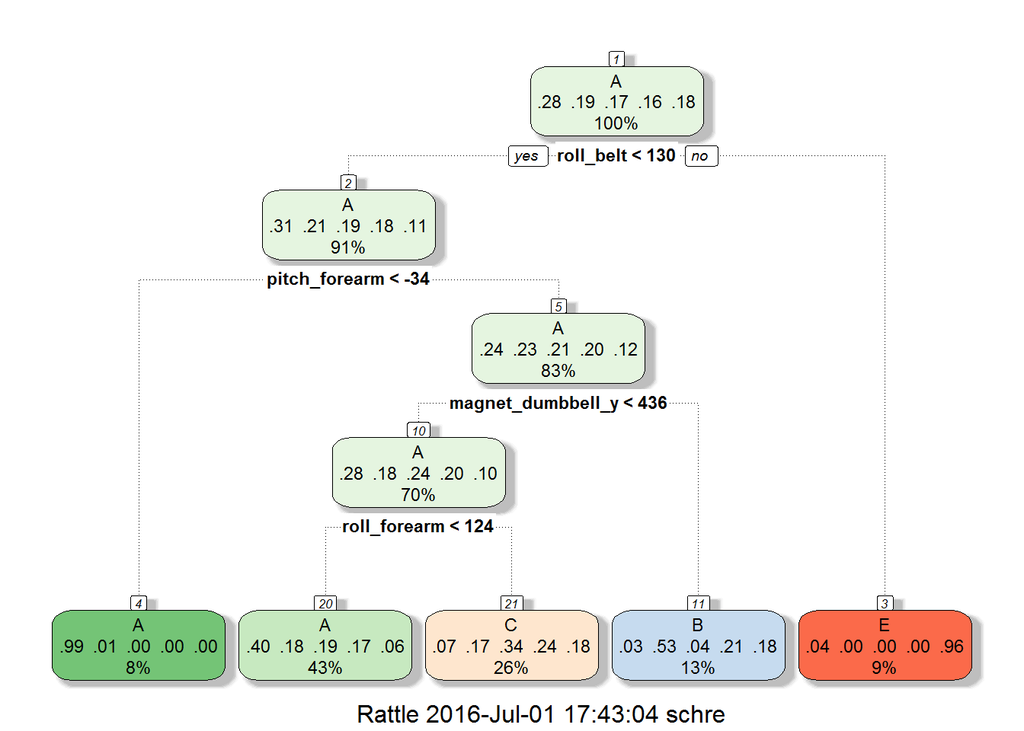

```r
set.seed(5)
modFit1 <- train(classe ~ .,method="rpart",data=trainingSub1)
fancyRpartPlot(modFit1$finalModel)
```

```r
predictions1 <- predict(modFit1, newdata=trainingSub1)
confusionMatrix(predictions1, trainingSub1$classe)
```

```
## Confusion Matrix and Statistics
##
##           Reference
## Prediction    A    B    C    D    E
##          A 1682  516  525  487  164
##          B   28  452   36  178  156
##          C  129  298  580  407  311
##          D    0    0    0    0    0
##          E   21    0    0    0  572
##
## Overall Statistics
##
##                Accuracy : 0.5023
##                  95% CI : (0.4901, 0.5145)
##     No Information Rate : 0.2843
##     P-Value [Acc > NIR] : < 2.2e-16
##
##                   Kappa : 0.3499
##  Mcnemar's Test P-Value : NA
##
## Statistics by Class:
##
##                      Class: A Class: B Class: C Class: D Class: E
## Sensitivity            0.9043  0.35703  0.50833   0.0000  0.47548
## Specificity            0.6386  0.92456  0.78800   1.0000  0.99607
## Pos Pred Value         0.4985  0.53176  0.33623      NaN  0.96459
## Neg Pred Value         0.9438  0.85699  0.88354   0.8361  0.89393
## Prevalence             0.2843  0.19352  0.17441   0.1639  0.18389
## Detection Rate         0.2571  0.06909  0.08866   0.0000  0.08744
## Detection Prevalence   0.5157  0.12993  0.26368   0.0000  0.09065
## Balanced Accuracy      0.7715  0.64080  0.64816   0.5000  0.73577
```

As you can see this model’s confusionMatrix proves accuracy is rather low. So, let’s try it again with, this time with scaling and cross validation.

```r
set.seed(6)
modFit1 <- train(trainingSub1$classe ~ .,  preProcess=c("center", "scale"), trControl=trainControl(method = "cv", number = 4), data = trainingSub1, method="rpart")
predictions1 <- predict(modFit1, newdata=trainingSub1)
confusionMatrix(predictions1, trainingSub1$classe)
```

```
## Confusion Matrix and Statistics
##
##           Reference
## Prediction    A    B    C    D    E
##          A 1682  516  525  487  164
##          B   28  452   36  178  156
##          C  129  298  580  407  311
##          D    0    0    0    0    0
##          E   21    0    0    0  572
##
## Overall Statistics
##
##                Accuracy : 0.5023
##                  95% CI : (0.4901, 0.5145)
##     No Information Rate : 0.2843
##     P-Value [Acc > NIR] : < 2.2e-16
##
##                   Kappa : 0.3499
##  Mcnemar's Test P-Value : NA
##
## Statistics by Class:
##
##                      Class: A Class: B Class: C Class: D Class: E
## Sensitivity            0.9043  0.35703  0.50833   0.0000  0.47548
## Specificity            0.6386  0.92456  0.78800   1.0000  0.99607
## Pos Pred Value         0.4985  0.53176  0.33623      NaN  0.96459
## Neg Pred Value         0.9438  0.85699  0.88354   0.8361  0.89393
## Prevalence             0.2843  0.19352  0.17441   0.1639  0.18389
## Detection Rate         0.2571  0.06909  0.08866   0.0000  0.08744
## Detection Prevalence   0.5157  0.12993  0.26368   0.0000  0.09065
## Balanced Accuracy      0.7715  0.64080  0.64816   0.5000  0.73577
```

There was little to no improvement with scaling and cross validation using Decision Trees. For the 2nd model I decided to then use Random Forest, which should provide better accuracy.

```r
#Random Forest
set.seed(7)
modFit2 <- train(trainingSub2$classe ~ ., method="rf", preProcess=c("center", "scale"), trControl=trainControl(method = "cv", number = 4), data=trainingSub2)
predictions2 <- predict(modFit2,trainingSub2)
confusionMatrix(predictions2, trainingSub2$classe)
```

```
## Confusion Matrix and Statistics
##
##           Reference
## Prediction    A    B    C    D    E
##          A 1860    0    0    0    0
##          B    0 1266    0    0    0
##          C    0    0 1141    0    0
##          D    0    0    0 1072    0
##          E    0    0    0    0 1202
##
## Overall Statistics
##
##                Accuracy : 1
##                  95% CI : (0.9994, 1)
##     No Information Rate : 0.2844
##     P-Value [Acc > NIR] : < 2.2e-16
##
##                   Kappa : 1
##  Mcnemar's Test P-Value : NA
##
## Statistics by Class:
##
##                      Class: A Class: B Class: C Class: D Class: E
## Sensitivity            1.0000   1.0000   1.0000   1.0000   1.0000
## Specificity            1.0000   1.0000   1.0000   1.0000   1.0000
## Pos Pred Value         1.0000   1.0000   1.0000   1.0000   1.0000
## Neg Pred Value         1.0000   1.0000   1.0000   1.0000   1.0000
## Prevalence             0.2844   0.1935   0.1744   0.1639   0.1838
## Detection Rate         0.2844   0.1935   0.1744   0.1639   0.1838
## Detection Prevalence   0.2844   0.1935   0.1744   0.1639   0.1838
## Balanced Accuracy      1.0000   1.0000   1.0000   1.0000   1.0000
```

```r
print(modFit2, digits=3)
```

```
## Random Forest
##
## 6541 samples
##   52 predictor
##    5 classes: 'A', 'B', 'C', 'D', 'E'
##
## Pre-processing: centered (52), scaled (52)
## Resampling: Cross-Validated (4 fold)
## Summary of sample sizes: 4907, 4906, 4904, 4906
## Resampling results across tuning parameters:
##
##   mtry  Accuracy  Kappa
##    2    0.976     0.969
##   27    0.979     0.974
##   52    0.972     0.965
##
## Accuracy was used to select the optimal model using  the largest value.
## The final value used for the model was mtry = 27.
```

As expected, accuracy is much improved, nearing 100%. But with 50+ predictors we may be over-fitting. Let’s try this model using training set #3, which should give us a reasonable expectation of the error rate on the Testing dataset.

```r
predictions3 <- predict(modFit2,trainingSub3)
confusionMatrix(predictions3, trainingSub3$classe)
```

```
## Confusion Matrix and Statistics
##
##           Reference
## Prediction    A    B    C    D    E
##          A 1859   38    0    0    0
##          B    1 1217   12    3    1
##          C    0    9 1122   27    2
##          D    0    0    6 1040    7
##          E    0    1    0    2 1192
##
## Overall Statistics
##
##                Accuracy : 0.9833
##                  95% CI : (0.9799, 0.9863)
##     No Information Rate : 0.2844
##     P-Value [Acc > NIR] : < 2.2e-16
##
##                   Kappa : 0.9789
##  Mcnemar's Test P-Value : NA
##
## Statistics by Class:
##
##                      Class: A Class: B Class: C Class: D Class: E
## Sensitivity            0.9995   0.9621   0.9842   0.9701   0.9917
## Specificity            0.9919   0.9968   0.9930   0.9976   0.9994
## Pos Pred Value         0.9800   0.9862   0.9672   0.9877   0.9975
## Neg Pred Value         0.9998   0.9910   0.9967   0.9942   0.9981
## Prevalence             0.2844   0.1935   0.1743   0.1639   0.1838
## Detection Rate         0.2843   0.1861   0.1716   0.1590   0.1823
## Detection Prevalence   0.2901   0.1887   0.1774   0.1610   0.1827
## Balanced Accuracy      0.9957   0.9794   0.9886   0.9839   0.9956
```

Our out-of-sample error rate is expected to be approximately 1.0 - 0.9833 = 0.0167. So, let’s now apply the final model to our testing dataset

```r
predictionTesting <- predict(modFit2, newdata=testing)
predictionTesting
```

```
##  [1] B A A A A E D B A A B C B A E E A B B B
## Levels: A B C D E
```

## Conclusion

Early attempts at using Decision Trees, while fast, did not provide much accuracy. An initial attempt at using Random Forest proved to be much too slow, even after eliminating as many variables as possible. Dividing the traning set into three roughly equal sized data sets allowed for quicker analysis using Random Forest and fullfilled the role of a validation set in order to predict the out-of-sample error rate of 0.0167.